```python
from __future__ import print_function

from functools import partial
import itertools as itr
import warnings

import matplotlib.pyplot as plt
import numpy as np
import pandas as pd
import scipy as sp
from scipy import integrate
```

```python
warnings.filterwarnings('ignore')
plt.subplots = partial(plt.subplots, facecolor='none', dpi=120)
plt.cm.jet.set_under('white')
np.random.seed(0)
```

# Introduction

Inspired by the neutron evaporation model that states $$ f(E) \ dE \propto Ee^{-E/T} \ dE \ , $$ we propose a hypothetical yield density (distribution), $$ \frac{d^2Y}{dEd\Omega}(E, \theta) \propto E\exp\left(-\frac{E}{50}\cdot\frac{1}{1+\sin^2\theta}\right) \ . $$ The $\theta$ dependence has no reference from any physical model. It is only introduced to make the emission anisotropic.

Normalization requires $$ \int_0^\infty dE \int d\Omega \ \frac{d^2Y}{dEd\Omega} = M \ , $$ where $M$ is the expected total multiplicity from a single collision event. We shall set $M:=1$ in the remaining of this notebook, then it can be found that $$ \frac{d^2Y}{dEd\Omega} = \frac{3E}{86000\pi}\exp\left(-\frac{E}{50}\cdot\frac{1}{1+\sin^2\theta}\right) \ . $$ Also, the unit has been assumed to be $\mathrm{MeV}$ for energy and radian for angles (degree is used only when plotting). So, for instance, the $50$ inside the exponential should really be $50~\mathrm{MeV}$ in order to cancel out the unit of $E$; same for $86000$.

```python
def d2Y(E, theta, isotropic=False):
    if isotropic: # for debug/develop purpose only
        A = 1.0 / (40000 * np.pi)
        return A * E * np.exp(- E / 100)
    else:
        A = 3.0 / (86000 * np.pi)
        return A * E * np.exp(- (E / 50) / (1 + (np.sin(theta))**2) )
```

# Monte Carlo: Generate random $(E, \theta, \varphi)$ samples

Notice that $\dfrac{d^2Y}{dEd\Omega}$ is symmetric around $\theta=\pi/2$ and independent of $\varphi$. In fact, for any given $E$, $\theta=\pi/2$ gives the highest probability. So to look for the most probable $(E, \theta, \varphi)$, we only need to look for the maximum of $E$ with $\theta:=\pi/2$, hence $\sin^2\theta=1$. This is done by solving $$ \frac{d}{dE} Ee^{-E/100} = 0 \hspace{5pt}\Longrightarrow\hspace{5pt} E = 100 \ . $$ Therefore, the most probable $(E, \theta, \varphi)$ is $(100, \pi/2, 0)$. This result is useful for us to draw random sample of $(E, \theta, \varphi)$.

```python
NDRAWS = int(5e7)
E_MAX = 1000
ISOTROPIC = False

data = pd.DataFrame({'E': np.random.uniform(high=E_MAX, size=NDRAWS),
                     'theta': np.random.uniform(high=np.pi, size=NDRAWS)})
obs_d2Y = np.sin(data['theta']) * d2Y(data['E'], data['theta'], isotropic=ISOTROPIC)
max_d2Y = np.sin(0.5*np.pi) * d2Y(100.0, 0.5*np.pi, isotropic=ISOTROPIC)
draw_d2Y = np.random.uniform(high=max_d2Y, size=NDRAWS)
data = data[draw_d2Y < obs_d2Y]
n_particles = len(data)
data['phi'] = np.random.uniform(high=2*np.pi, size=n_particles)
data
```

|  | E | theta | phi |
| --- | --- | --- | --- |
| 15 | 87.129300 | 0.776080 | 2.644892 |
| 34 | 18.789800 | 1.332132 | 5.146794 |
| 36 | 612.095723 | 2.140921 | 1.684682 |
| 43 | 60.225472 | 1.739130 | 0.429571 |
| 44 | 666.766715 | 2.284927 | 4.437669 |
| 46 | 210.382561 | 1.431842 | 2.228107 |
| 53 | 102.044811 | 1.007247 | 1.217839 |
| 54 | 208.876756 | 1.432329 | 5.212685 |
| 55 | 161.309518 | 1.137982 | 0.119794 |
| 59 | 244.425592 | 0.902418 | 5.547063 |
| 60 | 158.969584 | 1.809142 | 5.301246 |
| 69 | 96.098408 | 0.764220 | 5.617729 |
| 79 | 118.727719 | 2.752397 | 1.394621 |
| 82 | 64.147496 | 2.033098 | 0.999501 |
| 87 | 93.940511 | 1.905446 | 1.741700 |
| 90 | 318.568952 | 1.287775 | 5.888211 |
| 132 | 135.474064 | 0.302865 | 4.714609 |
| 152 | 162.492935 | 1.575861 | 2.230643 |
| 166 | 11.714084 | 3.000787 | 3.553719 |
| 171 | 54.337988 | 1.973094 | 1.555546 |
| 179 | 31.838930 | 1.305873 | 6.209387 |
| 180 | 164.694156 | 2.467069 | 2.376352 |
| 192 | 186.193006 | 1.694751 | 4.657417 |
| 197 | 254.356482 | 1.682604 | 4.890986 |
| 203 | 179.603678 | 0.643773 | 2.916874 |
| 204 | 24.678728 | 1.696286 | 3.963477 |
| 213 | 263.322377 | 1.530928 | 3.346638 |
| 216 | 320.017151 | 1.470221 | 5.651418 |
| 231 | 213.311977 | 0.904747 | 2.319650 |
| 233 | 25.662718 | 1.927241 | 2.920717 |
| ... | ... | ... | ... |
| 49999761 | 246.201082 | 1.161794 | 1.752868 |
| 49999764 | 156.279354 | 2.507100 | 3.286266 |
| 49999772 | 112.253675 | 1.263797 | 6.074182 |
| 49999778 | 54.726723 | 1.540323 | 0.240932 |
| 49999781 | 129.684194 | 1.968147 | 5.079776 |
| 49999785 | 46.864073 | 1.291323 | 3.639729 |
| 49999789 | 67.670080 | 2.924635 | 2.816470 |
| 49999790 | 146.916012 | 1.860823 | 4.433152 |
| 49999791 | 151.978982 | 1.040803 | 3.743020 |
| 49999792 | 254.307556 | 1.472811 | 3.508708 |
| 49999801 | 119.257972 | 0.762610 | 5.988191 |
| 49999809 | 571.254474 | 1.735828 | 5.446945 |
| 49999812 | 170.001831 | 0.722332 | 3.138068 |
| 49999819 | 227.920273 | 1.051922 | 3.070570 |
| 49999846 | 84.496541 | 0.880475 | 3.979803 |
| 49999855 | 36.176650 | 0.745899 | 6.241123 |
| 49999861 | 174.364134 | 1.951214 | 2.518626 |
| 49999862 | 155.314520 | 1.523547 | 1.258534 |
| 49999873 | 106.181760 | 0.732986 | 5.768806 |
| 49999878 | 27.555017 | 1.815296 | 6.193920 |
| 49999887 | 451.434011 | 2.397455 | 2.459776 |
| 49999895 | 174.811682 | 1.234488 | 1.471841 |
| 49999899 | 12.356236 | 1.306243 | 2.516219 |
| 49999904 | 125.966607 | 1.193018 | 3.342723 |
| 49999921 | 63.228386 | 1.563820 | 2.526913 |
| 49999923 | 270.724534 | 2.362587 | 4.267356 |
| 49999929 | 22.458099 | 1.803905 | 6.008674 |
| 49999938 | 167.496842 | 2.032778 | 5.436028 |
| 49999950 | 256.972585 | 1.589684 | 5.344234 |
| 49999983 | 199.673566 | 1.439515 | 1.217950 |

6201046 rows × 3 columns

We have now generated many data $(E, \theta, \varphi)$ that follow the distribution given by $\frac{d^2Y}{dEd\theta}$. One common pitfall when drawing random samples involving $\theta$ is to forget about the $\sin\theta$ factor. Remember that $d\Omega$ is really just a shorthand for $$ d\Omega = \sin\theta \ d\theta \ d\varphi \ . $$ This is because when we drawing random $\theta$ samples, we should use the distribution that looks like $\frac{dY}{d\theta}$ instead of $\frac{dY}{d\Omega}$.

Just as a final check, we can always look at the count distribution of $\theta$ that we generate. If the sampling is correct, then for $\frac{d^2Y}{dEd\theta}$ that has no singularity (easiest example would be isotropic emission), the counts should go to zero at $\theta = 0$ and $\theta = \pi$. Otherwise, when we actually plot on a spherical surface, there will be infinite densities at the north pole and the south pole, which is unphysical.

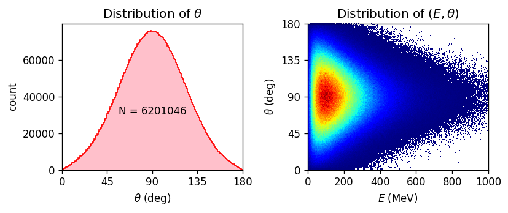

```python
fig, ax = plt.subplots(ncols=2, figsize=(7, 3))

ax[0].set_title(r'Distribution of $\theta$')
ax[0].hist(np.degrees(data['theta']), range=[0, 180], bins=180,
           histtype='stepfilled', edgecolor='red', facecolor='pink')
ax[0].annotate('N = {}'.format(n_particles), xy=(0, 0), textcoords='axes fraction', xytext=(0.5, 0.4),
               ha='center', va='center')
ax[0].set_xlabel(r'$\theta$ (deg)'); ax[0].set_xlim(0, 180); ax[0].set_xticks(np.linspace(0, 180, 5))
ax[0].set_ylabel(r'count'); ax[0].set_ylim(0, );

ax[1].set_title(r'Distribution of $(E, \theta)$')
ax[1].hist2d(data['E'], np.degrees(data['theta']), range=[[0, E_MAX], [0, 180]],
             bins=[250, 180], cmap=plt.cm.jet, vmin=1)
ax[1].set_xlabel(r'$E$ (MeV)'); ax[1].set_xlim(0, E_MAX);
ax[1].set_ylabel(r'$\theta$ (deg)'); ax[1].set_ylim(0, 180); ax[1].set_yticks(np.linspace(0, 180, 5))

plt.tight_layout()
plt.show()
```

# Data analysis

The remaining goal of this notebook is to reproduce the hypothetical differential yield distribution. In other words, how can we reconstruct back the physics from a collection of data $(E, \theta, \varphi)$?

## A perfect detector but with non-$4\pi$ coverage

To add spice to this whole problem, let's us make some constraints on the detectable ranges of $\theta$ and $\varphi$.

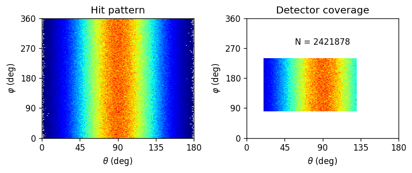

```python
fig, ax = plt.subplots(ncols=2, figsize=(7, 3))
c = 0
ax[c].set_title('Hit pattern')
ax[c].hist2d(np.degrees(data['theta']), np.degrees(data['phi']),
             range=[[0, 180], [0, 360]], bins=[180, 360],
             cmap=plt.cm.jet, vmin=1)
ax[c].set_xlabel(r'$\theta$ (deg)'); ax[c].set_xlim(0, 180); ax[c].set_xticks(np.linspace(0, 180, 5));
ax[c].set_ylabel(r'$\varphi$ (deg)'); ax[c].set_ylim(0, 360); ax[c].set_yticks(np.linspace(0, 360, 5));

c = 1
detector = {'theta_range': np.radians([20, 130]),
            'phi_range': np.radians([80, 240])}
detector_mask = ((data['theta'] > detector['theta_range'][0]) & \
                 (data['theta'] < detector['theta_range'][1]) & \
                 (data['phi'] > detector['phi_range'][0]) & \
                 (data['phi'] < detector['phi_range'][1]))
data_det = data[detector_mask] # apply detector filter
# data_det = data.copy() # no detector
ax[c].set_title('Detector coverage')
ax[c].hist2d(np.degrees(data_det['theta']), np.degrees(data_det['phi']),
             range=[[0, 180], [0, 360]], bins=[180, 360],
             cmap=plt.cm.jet, vmin=1)
ax[c].annotate('N = {}'.format(len(data_det)), xy=(0, 0), textcoords='axes fraction', xytext=(0.5, 0.8),
               ha='center', va='center')
ax[c].set_xlabel(r'$\theta$ (deg)'); ax[c].set_xlim(0, 180); ax[c].set_xticks(np.linspace(0, 180, 5));
ax[c].set_ylabel(r'$\varphi$ (deg)'); ax[c].set_ylim(0, 360); ax[c].set_yticks(np.linspace(0, 360, 5));

plt.tight_layout()
plt.show()
```

## Energy spectra at different $\theta$

In an experiment, we are often interested in reconstructing the energy spectra at different $\theta$ values:

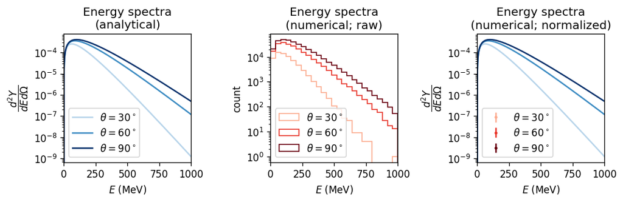

```python
fig, ax = plt.subplots(ncols=3, figsize=(9, 3))
ene = np.linspace(0, E_MAX, E_MAX+1)
theta_of_interest = np.radians(np.arange(30, 91, 30))

c = 0
ax[c].set_title('Energy spectra\n(analytical)')
colors = plt.cm.Blues(np.linspace(0.3, 1.0, len(theta_of_interest)))
for theta, color in zip(theta_of_interest, colors):
    y = d2Y(ene, theta=theta, isotropic=ISOTROPIC)
    ax[c].plot(ene, y, color=color, label=r'$\theta=%.0f^\circ$' % np.degrees(theta))
ax[c].legend(loc='lower left')
ax[c].set_xlabel(r'$E$ (MeV)'); ax[c].set_xlim(0, E_MAX);
ax[c].set_ylabel(r'$\dfrac{d^2Y}{dEd\Omega}~(\mathrm{/MeV/sr})$'); ax[c].set_yscale('log');

c = 1
ax[c].set_title('Energy spectra\n(numerical; raw)')
colors = plt.cm.Reds(np.linspace(0.3, 1.0, len(theta_of_interest)))
for theta, color in zip(theta_of_interest, colors):
    dtheta = np.radians(10.0) # not-too-big interval
    df = data_det[(data_det['theta'] > theta - 0.5*dtheta) &
                  (data_det['theta'] < theta + 0.5*dtheta)]
    hrange, hbins = [0, E_MAX], 25

    ax[c].hist(df['E'], range=hrange, bins=hbins,
               color=color, histtype='step',
               label=r'$\theta=%.0f^\circ$' % np.degrees(theta))
ax[c].legend(loc='lower left')
ax[c].set_xlabel(r'$E$ (MeV)'); ax[c].set_xlim(0, E_MAX);
ax[c].set_ylabel('count'); ax[c].set_yscale('log');

c = 2
ax[c].set_title('Energy spectra\n(numerical; normalized)')
colors = plt.cm.Blues(np.linspace(0.3, 1.0, len(theta_of_interest)))
for theta, color in zip(theta_of_interest, colors):
    y = d2Y(ene, theta=theta, isotropic=ISOTROPIC)
    ax[c].plot(ene, y, color=color)
colors = plt.cm.Reds(np.linspace(0.3, 1.0, len(theta_of_interest)))
for theta, color in zip(theta_of_interest, colors):
    dtheta = np.radians(10.0) # not-too-big interval
    df = data_det[(data_det['theta'] > theta - 0.5*dtheta) &
                  (data_det['theta'] < theta + 0.5*dtheta)]
    hrange, hbins = [0, E_MAX], 25

    y, x = np.histogram(df['E'], range=hrange, bins=hbins)
    x = 0.5 * (x[1:] + x[:-1])
    yerr_frac = np.nan_to_num(1.0 / np.sqrt(y))

    # normalization
    y = y / n_particles
    y = y / (x[1] - x[0])
    y = y / (np.sin(theta) * dtheta)
    y = y / (detector['phi_range'][1] - detector['phi_range'][0])
    yerr = y * yerr_frac

    ax[c].errorbar(x, y, yerr=yerr,
                   fmt='o', ms=2, color=color, zorder=4,
                   label=r'$\theta=%.0f^\circ$' % np.degrees(theta))
ax[c].legend(loc='lower left')
ax[c].set_xlabel(r'$E$ (MeV)'); ax[c].set_xlim(0, E_MAX);
ax[c].set_ylabel(r'$\dfrac{d^2Y}{dEd\Omega}~(\mathrm{/MeV/sr})$'); ax[c].set_yscale('log');

plt.tight_layout()
plt.show()
```

The analytic energy spectrum at $\theta = \theta_0$ is simply given by $$ \frac{d^2Y}{dEd\Omega}(E, \theta_0) \ . $$

When we try to reconstruct the energy spectrum at $\theta = \theta_0$, we may introduce a filter that selects particles that fall within $$ \theta\in[\theta_0-\delta\theta, \theta_0+\delta\theta] \ , $$ where $\delta\theta$ is some "small interval". The determination of "small interval" is usually made after balancing the following two considerations:

1. There has to be enough statistics around $\theta_0\pm\delta\theta$.
2. The energy spectrum is sufficiently flat over the range of $\theta_0\pm\delta\theta$.

The first requirement limits how small $\delta\theta$ can be, whereas the second requirement limits how big $\delta\theta$ can be. From my experience, the energy spectrum does not vary significantly over a range of $\theta=10^\circ$. So a successful experiment would have to collect sufficient data such that it can guarantee enough statistics in every $10$-degree slice of interest.

## On normalizing energy spectrum

In the previous code cell, normalization was made as below:

```
y, x = np.histogram(data_det['E'])
x = 0.5 * (x[1:] + x[:-1]) # calculate bin center
y = y / n_particles
y = y / (x[1] - x[0]) # dE
y = y / (np.sin(theta) * dtheta)
y = y / (detector['phi_range'][1] - detector['phi_range'][0]) # dphi
```

These steps can be understood with $$ \frac{d^2Y}{dEd\Omega}(E_0, \theta_0) \approx \frac{N_\mathrm{count}}{N_\mathrm{total}\cdot\delta E\cdot\delta\Omega} \ , $$ where $N_\mathrm{count}$ is the number of particles observed within the phase space of $E_0\pm\frac{1}{2}\delta E$ and $\theta_0\pm\frac{1}{2}\delta\theta$, i.e. the bin contents of a 2D histogram.

Then we rewrite $d\Omega$ so that the yield density becomes $$ \frac{d^2Y}{dEd\Omega}(E_0, \theta_0) \approx \frac{N_\mathrm{count}}{N_{total}\cdot\delta E\cdot(\delta\varphi\cdot\sin\theta \ \delta\theta)} \ . $$ Typically, we assume azimuthal symmetry, so $\delta\varphi$ can be taken as large as we wish without affecting the estimation. If the detector coverage is a rectangle in $(\theta, \varphi)$ space, just like in this pedagogical example, we simply take the $\varphi$ range as $\delta\varphi$ (a realistic coverage involves "geometry efficiency", which will be discussed later). In other words, the $N_\mathrm{count}$ counts any observed particles near $E=E_0$ and $\theta=\theta_0$ regardless of its $\varphi$ value.

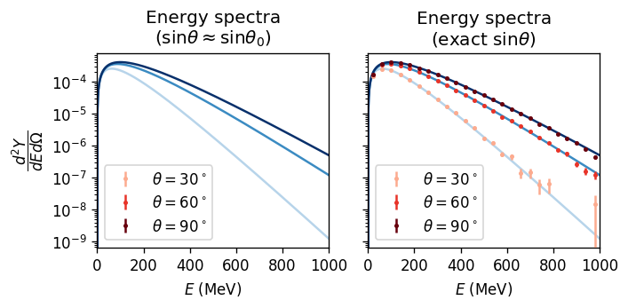

```python
fig, ax = plt.subplots(ncols=2, figsize=(6, 3), sharey=True)
ene = np.linspace(0, E_MAX, E_MAX+1)
theta_of_interest = np.radians(np.arange(30, 91, 30))

c = 0
ax[c].set_title('Energy spectra\n'+r'($\sin\theta\approx\sin\theta_0$)')
colors = plt.cm.Blues(np.linspace(0.3, 1.0, len(theta_of_interest)))
for theta, color in zip(theta_of_interest, colors):
    y = d2Y(ene, theta=theta, isotropic=ISOTROPIC)
    ax[c].plot(ene, y, color=color)
colors = plt.cm.Reds(np.linspace(0.3, 1.0, len(theta_of_interest)))
for theta, color in zip(theta_of_interest, colors):
    dtheta = np.radians(10.0) # not-too-big interval
    df = data_det[(data_det['theta'] > theta - 0.5*dtheta) &
                  (data_det['theta'] < theta + 0.5*dtheta)]
    hrange, hbins = [0, E_MAX], 25

    y, x = np.histogram(df['E'], range=hrange, bins=hbins)
    yerr_frac = np.nan_to_num(1.0 / np.sqrt(y))
    x = 0.5 * (x[1:] + x[:-1])

    # normalization
    y = y / n_particles
    y = y / (x[1] - x[0])
    y = y / (np.sin(theta) * dtheta)
    y = y / (detector['phi_range'][1] - detector['phi_range'][0])
    yerr = y * yerr_frac

    ax[c].errorbar(x, y, yerr=yerr,
                   fmt='o', ms=2, color=color, zorder=4,
                   label=r'$\theta=%.0f^\circ$' % np.degrees(theta))
ax[c].legend(loc='lower left')
ax[c].set_xlabel(r'$E$ (MeV)'); ax[c].set_xlim(0, E_MAX);
ax[c].set_ylabel(r'$\dfrac{d^2Y}{dEd\Omega}~(\mathrm{/MeV/sr})$'); ax[c].set_yscale('log');

c = 1
ax[c].set_title('Energy spectra\n'+r'(exact $\sin\theta$)')
colors = plt.cm.Blues(np.linspace(0.3, 1.0, len(theta_of_interest)))
for theta, color in zip(theta_of_interest, colors):
    y = d2Y(ene, theta=theta, isotropic=ISOTROPIC)
    ax[c].plot(ene, y, color=color)
colors = plt.cm.Reds(np.linspace(0.3, 1.0, len(theta_of_interest)))
for theta, color in zip(theta_of_interest, colors):
    dtheta = np.radians(10.0) # not-too-big interval
    df = data_det[(data_det['theta'] > theta - 0.5*dtheta) &
                  (data_det['theta'] < theta + 0.5*dtheta)]
    hrange, hbins = [0, E_MAX], 25

    y, _ = np.histogram(df['E'], range=hrange, bins=hbins)
    yerr_frac = np.nan_to_num(1.0 / np.sqrt(y))

    weights = np.ones(len(df)) / np.sin(df['theta'])
    y, x = np.histogram(df['E'], range=hrange, bins=hbins, weights=weights)
    x = 0.5 * (x[1:] + x[:-1])

    # normalization
    y = y / n_particles
    y = y / (x[1] - x[0])
    y = y / dtheta
    y = y / (detector['phi_range'][1] - detector['phi_range'][0])
    yerr = y * yerr_frac

    ax[c].errorbar(x, y, yerr=yerr,
                   fmt='o', ms=2, color=color, zorder=4,
                   label=r'$\theta=%.0f^\circ$' % np.degrees(theta))
ax[c].legend(loc='lower left')
ax[c].set_xlabel(r'$E$ (MeV)'); ax[c].set_xlim(0, E_MAX);
# ax[c].set_ylabel(r'$\dfrac{d^2Y}{dEd\Omega}~(\mathrm{/MeV/sr})$'); ax[c].set_yscale('log');

plt.tight_layout()
plt.show()
```

When normalizing energy spectrum, there are two different ways to take care of $\sin\theta$ in the expresion below: $$ \frac{d^2Y}{dEd\Omega}(E_0, \theta_0) \approx \frac{N_\mathrm{count}}{N_{total}\cdot\delta E\cdot(\delta\varphi\cdot\sin\theta \ \delta\theta)} \ . $$ First, we may simply approximate $\sin\theta\approx\sin\theta_0$. Alternatively, we may use the exact $\sin\theta$ values by introducing them as weights when filling histogram. The python code below demonstrates the idea:

```
weights = np.ones(len(df)) / np.sin(df['theta'])
y, x = np.histogram(df['E'], weights=weights)
x = 0.5 * (x[1:] + x[:-1])
y = y / n_particles
y = y / (x[1] - x[0]) # dE
y = y / dtheta # dtheta
y = y / (detector['phi_range'][1] - detector['phi_range'][0]) # dphi
```

## Energy spectrum over a large $\theta$ range

Sometimes, we are so limited by statistics that we are forced to look at energy spectrum accummulated over a significant range of $\theta$, e.g. a range like $30^\circ$ to $120^\circ$ can most likely be considered "large" and it will *not* represent the energy spectrum at its mean value, $(30^\circ + 120^\circ) / 2 = 75^\circ$.

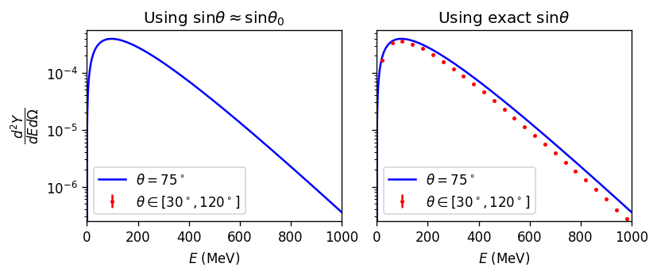

```python
fig, ax = plt.subplots(ncols=2, figsize=(7, 3), sharey=True)
ene = np.linspace(0, E_MAX, E_MAX+1)
theta_range = np.radians([30, 120])
dtheta = theta_range[1] - theta_range[0] # a large one
theta = theta_range.mean()
y_analy = d2Y(ene, theta=theta, isotropic=ISOTROPIC)

# $\sin\theta \approx \sin\theta_0$
c = 0
ax[c].set_title(r'Using $\sin\theta\approx\sin\theta_0$')
ax[c].plot(ene, y_analy, color='blue', label=r'$\theta=%.0f^\circ$' % np.degrees(theta))
df = data_det[(data_det['theta'] > theta_range[0]) &
              (data_det['theta'] < theta_range[1])]
hrange, hbins = [0, E_MAX], 25
y, x = np.histogram(df['E'], range=hrange, bins=hbins)
x = 0.5 * (x[1:] + x[:-1])
yerr_frac = np.nan_to_num(1.0 / np.sqrt(y))

y = y / n_particles
y = y / (x[1] - x[0])
y = y / (np.sin(theta) * dtheta)
y = y / (detector['phi_range'][1] - detector['phi_range'][0])
yerr = y * yerr_frac

ax[c].errorbar(x, y, yerr=yerr, fmt='o', ms=2, color='red',
            label=r'$\theta\in[%.0f^\circ, %.0f^\circ]$' %
            (np.degrees(theta_range[0]), np.degrees(theta_range[1])))
ax[c].set_ylabel(r'$\dfrac{d^2Y}{dEd\Omega}~(\mathrm{/MeV/sr})$'); ax[c].set_yscale('log')

# exact $\sin\theta$
c = 1
ax[c].set_title(r'Using exact $\sin\theta$')
ax[c].plot(ene, y_analy, color='blue', label=r'$\theta=%.0f^\circ$' % np.degrees(theta))

y, x = np.histogram(df['E'], range=hrange, bins=hbins)
yerr_frac = np.nan_to_num(1.0 / np.sqrt(y))

weights = np.ones(len(df)) / np.sin(df['theta'])
y, x = np.histogram(df['E'], range=hrange, bins=hbins, weights=weights)
x = 0.5 * (x[1:] + x[:-1])

y = y / n_particles
y = y / (x[1] - x[0])
y = y / dtheta
y = y / (detector['phi_range'][1] - detector['phi_range'][0])
yerr = y * yerr_frac

ax[c].errorbar(x, y, yerr=yerr, fmt='o', ms=2, color='red',
            label=r'$\theta\in[%.0f^\circ, %.0f^\circ]$' %
            (np.degrees(theta_range[0]), np.degrees(theta_range[1])))

for axe in ax:
    axe.set_xlabel(r'$E$ (MeV)'); axe.set_xlim(0, E_MAX)
    axe.legend(loc='lower left')

plt.tight_layout()
plt.show()
```

As we can see from the above figures, neither approaches match the analytical energy spectrum at $\theta=75^\circ$. After all, for such a huge $\theta$ range, the energy spectrum we are considering has become an "average energy spectrum", rather than the one given by $$\frac{d^2Y}{dEd\Omega}(E, \theta=75^\circ) \ . $$ Instead, the analytic result that we should be comparing is $$ \frac{1}{\theta_2 - \theta_1}\int_{\theta_1}^{\theta_2} d\theta \ \frac{d^2Y}{dEd\Omega} \ . $$

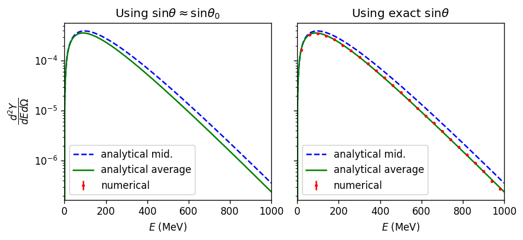

```python
fig, ax = plt.subplots(ncols=2, figsize=(7.5, 3.5), sharey=True)
y_analy_mid = d2Y(ene, theta=theta, isotropic=ISOTROPIC)
y_analy_range = []
for energy in ene:
    integrand = lambda theta: d2Y(energy, theta)
    y_analy_range.append(integrate.quad(integrand, theta_range[0], theta_range[1])[0])
y_analy_range = np.array(y_analy_range) / (theta_range[1] - theta_range[0])

# $\sin\theta \approx \sin\theta_0$
c = 0
ax[c].set_title(r'Using $\sin\theta\approx\sin\theta_0$')
ax[c].plot(ene, y_analy_mid, color='blue', linestyle='--', label='analytical mid.')
ax[c].plot(ene, y_analy_range, color='green', label='analytical average')
df = data_det[(data_det['theta'] > theta_range[0]) &
              (data_det['theta'] < theta_range[1])]
hrange, hbins = [0, E_MAX], 25
y, x = np.histogram(df['E'], range=hrange, bins=hbins)
x = 0.5 * (x[1:] + x[:-1])
yerr_frac = np.nan_to_num(1.0 / np.sqrt(y))

y = y / n_particles
y = y / (x[1] - x[0])
y = y / (np.sin(theta) * dtheta)
y = y / (detector['phi_range'][1] - detector['phi_range'][0])
yerr = y * yerr_frac

ax[c].errorbar(x, y, yerr=yerr, fmt='o', ms=2, color='red', label='numerical')
ax[c].set_ylabel(r'$\dfrac{d^2Y}{dEd\Omega}~(\mathrm{/MeV/sr})$'); ax[c].set_yscale('log')

# exact $\sin\theta$
c = 1
ax[c].set_title(r'Using exact $\sin\theta$')
ax[c].plot(ene, y_analy_mid, color='blue', linestyle='--', label='analytical mid.')
ax[c].plot(ene, y_analy_range, color='green', label='analytical average')

y, x = np.histogram(df['E'], range=hrange, bins=hbins)
yerr_frac = np.nan_to_num(1.0 / np.sqrt(y))

weights = np.ones(len(df)) / np.sin(df['theta'])
y, x = np.histogram(df['E'], range=hrange, bins=hbins, weights=weights)
x = 0.5 * (x[1:] + x[:-1])

y = y / n_particles
y = y / (x[1] - x[0])
y = y / dtheta
y = y / (detector['phi_range'][1] - detector['phi_range'][0])
yerr = y * yerr_frac

ax[c].errorbar(x, y, yerr=yerr, fmt='o', ms=2, color='red', label=r'numerical')

for axe in ax:
    axe.set_xlabel(r'$E$ (MeV)'); axe.set_xlim(0, E_MAX)
    axe.legend(loc='lower left')

plt.tight_layout()
plt.show()
```

## Energy spectrum as a projection from 2D histogram

Sometimes, we do not have access to the raw $(E, \theta, \varphi)$ data. For instance, due to storage limitation, it is only feasible to store analyzed data in terms of 2D histogram $(E, \theta)$. In that case, we have to construct the energy spectrum by projecting region within some $\theta$ cut onto the $E$-axis.

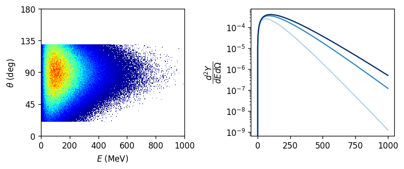

```python
fig, ax = plt.subplots(ncols=2, figsize=(7,3))

c = 0
h, x, y, _ = ax[c].hist2d(data_det['E'], np.degrees(data_det['theta']),
                          range=[[0, E_MAX], [0, 180]], bins=[E_MAX, 180],
                          cmap=plt.cm.jet, vmin=1)
x = 0.5 * (x[1:] + x[:-1])
y = 0.5 * (y[1:] + y[:-1])
ax[c].set_xlabel(r'$E$ (MeV)'); ax[c].set_xlim(0, E_MAX)
ax[c].set_ylabel(r'$\theta$ (deg)'); ax[c].set_ylim(0, 180); ax[c].set_yticks(np.linspace(0, 180, 5))

c = 1
ene = np.linspace(0, E_MAX, E_MAX+1)
theta_of_interest = np.radians([30, 60, 90])
colors = plt.cm.Blues(np.linspace(0.3, 1, len(theta_of_interest)))
for theta, color in zip(theta_of_interest, colors):
    y_analy = d2Y(ene, theta, isotropic=ISOTROPIC)
    ax[c].plot(ene, y_analy, color=color, label=r'$\theta=%.0f^\circ$' % np.degrees(theta))
xx, yy = np.meshgrid(x, y, indexing='ij')


ax[c].set_ylabel(r'$\dfrac{d^2Y}{dEd\Omega}~(\mathrm{/MeV/sr})$'); ax[c].set_yscale('log')

plt.tight_layout()
plt.show()
```

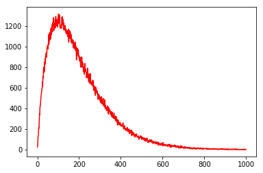

```python
theta_range = np.array([85, 95])
mask = ((yy > theta_range[0]) & (yy < theta_range[1]))
h_ = h[mask]
xx_ = xx[mask]
cats = sorted(set(xx_))
proj = np.bincount(np.searchsorted(cats, xx_), h_)
plt.plot(cats, proj, color='red')
```